# Prediction Of Weight Lifting Manner

Vladas Alesius

July 22, 2018

### Summary

The purpose of this project is to find an efficient way to predict the manner of weight lifting using respective dataset. For this aim, machine learning method called random forests is used. Comparison of results for training and testing subsets demonstrates that our algorithm prediction is highly accurate.

### Introduction

Human Activity Recognition (HAR) is a scientific research area that has been getting more and more attention in recent years. HAR has been applied in many different areas related to human health, such as elderly monitoring, weight loss programs, and digital assistance for weight lifting exercises.

Electronic devices help collect lots of data about human activity. Enthusiasts measure themselves to improve their health, discover behavioural patterns or simply for one’s interest. However, HAR research has been more focused on quantity of actions and distinguishing between them than on quality (i.e. how well a particular action is done).

In this project, we will use a dataset containing info about weight lifting. Six 20-28 year old men with little weight lifting experience were asked to perform one set of 10 repetitions of the Unilateral Dumbbell Biceps Curl in five different ways: exactly according to the specification (Class A), throwing the elbows to the front (Class B), lifting the dumbbell only halfway (Class C), lowering the dumbbell only halfway (Class D) and throwing the hips to the front (Class E). Class A corresponds to the correct execution of the exercise, while the other 4 classes correspond to common mistakes.

### Data Processing

Let’s begin with reading the initial training data set, defining values that we consider to be `NA`:

```r
data1<-read.csv("https://d396qusza40orc.cloudfront.net/predmachlearn/pml-training.csv",header = TRUE,
na.strings = c("NA","NaN","","#DIV/0!"))
```

The dataset contains 19622 entries and 160 features:

```r
dim(data1)
```

```
## [1] 19622   160
```

Feature names are listed below:

```r
colnames(data1)
```

```
##   [1] "X"                        "user_name"
##   [3] "raw_timestamp_part_1"     "raw_timestamp_part_2"
##   [5] "cvtd_timestamp"           "new_window"
##   [7] "num_window"               "roll_belt"
##   [9] "pitch_belt"               "yaw_belt"
##  [11] "total_accel_belt"         "kurtosis_roll_belt"
##  [13] "kurtosis_picth_belt"      "kurtosis_yaw_belt"
##  [15] "skewness_roll_belt"       "skewness_roll_belt.1"
##  [17] "skewness_yaw_belt"        "max_roll_belt"
##  [19] "max_picth_belt"           "max_yaw_belt"
##  [21] "min_roll_belt"            "min_pitch_belt"
##  [23] "min_yaw_belt"             "amplitude_roll_belt"
##  [25] "amplitude_pitch_belt"     "amplitude_yaw_belt"
##  [27] "var_total_accel_belt"     "avg_roll_belt"
##  [29] "stddev_roll_belt"         "var_roll_belt"
```

[output cut: 65 more lines]

As we can see, most features are related to movement data collected from belt, arm, dumbbell and forearm.

However, many features contain some `NA` data:

```r
str(data1,list.len=ncol(data1))
```

```
## 'data.frame':    19622 obs. of  160 variables:
##  $ X                       : int  1 2 3 4 5 6 7 8 9 10 ...
##  $ user_name               : Factor w/ 6 levels "adelmo","carlitos",..: 2 2 2 2 2 2 2 2 2 2 ...
##  $ raw_timestamp_part_1    : int  1323084231 1323084231 1323084231 1323084232 1323084232 1323084232 1323084232 1323084232 1323084232 1323084232 ...
##  $ raw_timestamp_part_2    : int  788290 808298 820366 120339 196328 304277 368296 440390 484323 484434 ...
##  $ cvtd_timestamp          : Factor w/ 20 levels "02/12/2011 13:32",..: 9 9 9 9 9 9 9 9 9 9 ...
##  $ new_window              : Factor w/ 2 levels "no","yes": 1 1 1 1 1 1 1 1 1 1 ...
##  $ num_window              : int  11 11 11 12 12 12 12 12 12 12 ...
##  $ roll_belt               : num  1.41 1.41 1.42 1.48 1.48 1.45 1.42 1.42 1.43 1.45 ...
##  $ pitch_belt              : num  8.07 8.07 8.07 8.05 8.07 8.06 8.09 8.13 8.16 8.17 ...
##  $ yaw_belt                : num  -94.4 -94.4 -94.4 -94.4 -94.4 -94.4 -94.4 -94.4 -94.4 -94.4 ...
##  $ total_accel_belt        : int  3 3 3 3 3 3 3 3 3 3 ...
##  $ kurtosis_roll_belt      : num  NA NA NA NA NA NA NA NA NA NA ...
##  $ kurtosis_picth_belt     : num  NA NA NA NA NA NA NA NA NA NA ...
##  $ kurtosis_yaw_belt       : logi  NA NA NA NA NA NA ...
```

[output cut: 146 more lines]

For some of them, `NA` makes the most values:

```r
sum(is.na(data1$kurtosis_roll_forearm))/length(data1$kurtosis_roll_forearm)
```

```
## [1] 0.9835898
```

It is sensible to remove features with mostly invalid data, so below we find out columns that contain more than 90% `NA` entries:

```r
ivect<-NULL
for (i in 1:ncol(data1)){
   if (sum(is.na(data1[,i]))/nrow(data1)>0.9) ivect<-c(ivect,i)
}
ivect
```

```
##   [1]  12  13  14  15  16  17  18  19  20  21  22  23  24  25  26  27  28
##  [18]  29  30  31  32  33  34  35  36  50  51  52  53  54  55  56  57  58
##  [35]  59  69  70  71  72  73  74  75  76  77  78  79  80  81  82  83  87
##  [52]  88  89  90  91  92  93  94  95  96  97  98  99 100 101 103 104 105
##  [69] 106 107 108 109 110 111 112 125 126 127 128 129 130 131 132 133 134
##  [86] 135 136 137 138 139 141 142 143 144 145 146 147 148 149 150
```

Those 100 columns are removed from the dataset below. As there are many such columns, number of features will decrease significantly:

```r
data1<-data1[,-ivect]
```

Also, the first 7 variables are not useful in forecasting either. Timestamp and window markers are not related to weight lifting, and person should also be unimportant, since all participants were closely supervised. We will remove them too:

```r
data1<-data1[,-(1:7)]
```

For our analysis, we will use functions from two `R` packages - `caret` and `randomForest`.

```r
library(caret)
library(randomForest)
```

Some variables can be highly correlated with each other. If highly correlated attributes are removed from the data, some machine learning models can perform better. In our case, 7 features should be removed:

```r
removeCol<-findCorrelation(cor(data1[,-53]))
removeCol
```

```
## [1] 10  1  9  8 31 33 18
```

```r
data1<-data1[,-removeCol]
```

The final dataset contains numeric or integer features with no `NA` values:

```r
dim(data1)
```

```
## [1] 19622    46
```

```r
str(data1,list.len=ncol(data1))
```

```
## 'data.frame':    19622 obs. of  46 variables:
##  $ pitch_belt          : num  8.07 8.07 8.07 8.05 8.07 8.06 8.09 8.13 8.16 8.17 ...
##  $ yaw_belt            : num  -94.4 -94.4 -94.4 -94.4 -94.4 -94.4 -94.4 -94.4 -94.4 -94.4 ...
##  $ total_accel_belt    : int  3 3 3 3 3 3 3 3 3 3 ...
##  $ gyros_belt_x        : num  0 0.02 0 0.02 0.02 0.02 0.02 0.02 0.02 0.03 ...
##  $ gyros_belt_y        : num  0 0 0 0 0.02 0 0 0 0 0 ...
##  $ gyros_belt_z        : num  -0.02 -0.02 -0.02 -0.03 -0.02 -0.02 -0.02 -0.02 -0.02 0 ...
##  $ magnet_belt_x       : int  -3 -7 -2 -6 -6 0 -4 -2 1 -3 ...
##  $ magnet_belt_y       : int  599 608 600 604 600 603 599 603 602 609 ...
##  $ magnet_belt_z       : int  -313 -311 -305 -310 -302 -312 -311 -313 -312 -308 ...
##  $ roll_arm            : num  -128 -128 -128 -128 -128 -128 -128 -128 -128 -128 ...
##  $ pitch_arm           : num  22.5 22.5 22.5 22.1 22.1 22 21.9 21.8 21.7 21.6 ...
##  $ yaw_arm             : num  -161 -161 -161 -161 -161 -161 -161 -161 -161 -161 ...
##  $ total_accel_arm     : int  34 34 34 34 34 34 34 34 34 34 ...
##  $ gyros_arm_y         : num  0 -0.02 -0.02 -0.03 -0.03 -0.03 -0.03 -0.02 -0.03 -0.03 ...
```

[output cut: 32 more lines]

```r
sum(is.na(data1))
```

```
## [1] 0
```

### Model Selection

Since our task is to predict the outcome variable (`classe`) based on multiple prediction variables, we will use machine learning techniques. **Machine learning (ML)** refers to different types of automated algorithms that automatically improve their prediction abilities through “learning” from the given data.

Our analysis will be related to the following ML methods:

- Decision trees - these algorithms split the data into multiple subsets, in order to make each subset as homogeneous as possible.
- Ensemble learning, in particular - **bagging** and **random forests**

Bagging means “bootstrap aggregating”. It takes a training dataset to build multiple different decision tree models by repeatedly using multiple bootstrapped subsets of the data and averaging the models. Each tree is build independently to the others.

Random forest is a type of bagging applied to decision trees. They provide a strong improvement in prediction compared to standard decision tree models. At each splitting step of the tree algorithm, a random sample of `n` predictors is chosen as split candidates from the full set of the predictors.

You can find more details and examples here: http://www.sthda.com/english/articles/35-statistical-machine-learning-essentials/141-cart-model-decision-tree-essentials/ http://www.sthda.com/english/articles/35-statistical-machine-learning-essentials/140-bagging-and-random-forest-essentials/

Since our aim is to achieve as high prediction accuracy as possible, we will choose random forest technique.

Firstly, we will generate a permutation of entries, so that their order does not affect the algorithm. To ensure reproducibility of the experiment, a seed is set.

```r
set.seed(100)
data1<-data1[sample(1:nrow(data1)),]
```

For model verification, our dataset will be split into two: training, which will be used to craft our model, and testing, that the model will be checked against. Training dataset will contain 80% of the initial data.

```r
training<-createDataPartition(data1$classe, p = 0.8, list = FALSE)
trainset<-data1[training,]
testset<-data1[-training,]
```

We have seen above that our predictors have values in different ranges - from decimals to hundreds. In order to avoid prediction inaccuracies related to different scale of variables, we will preprocess the data - center and scale it.

```r
preObj<-preProcess(trainset,c("center","scale"))
trainset<-predict(preObj,trainset)
```

Our random forest will be trained using `train` function from `caret` package in `R`. However, it takes a lot of time if default settings are used, so we will modify them.

Firstly, `train` function experiments on several `mtry` values (number of variables in trees). In order to select one, we will use `tuneRF` function from `randomForest` package. It searches for an optimal `mtry` value, comparing Out Of Bag error estimates. We start with `mtry`=`4`, and the lowest OOB value is for `mtry`=`16`. So this is the value of `mtry` that we will select for our model.

```r
tuneobj<-tuneRF(trainset[,-46],trainset[,46],mtryStart=4,stepFactor=2,plot=FALSE)
```

```
## mtry = 4  OOB error = 0.8%
## Searching left ...
## mtry = 2     OOB error = 1.06%
## -0.328 0.05
## Searching right ...
## mtry = 8     OOB error = 0.68%
## 0.144 0.05
## mtry = 16    OOB error = 0.63%
## 0.07476636 0.05
## mtry = 32    OOB error = 0.88%
## -0.3939394 0.05
```

Also, instead of default bootstrapping, the resampling method will be changed to 5-fold cross validation. This means that our training dataset will be split into 5 subsets. One subset will be reserved for testing and all other subsets will be used for training. The prediction error will be estimated for the test set. This process will be repeated until all subsets have served as test sets. The average of 5 prediction errors is called the cross-validation error.

```r
mod1<-train(classe~.,data=trainset,method = "rf",
  trControl = trainControl("cv", number = 5),verbose=FALSE,tuneGrid=data.frame(mtry=16))
mod1
```

```
## Random Forest
##
## 15699 samples
##    45 predictor
##     5 classes: 'A', 'B', 'C', 'D', 'E'
##
## No pre-processing
## Resampling: Cross-Validated (5 fold)
## Summary of sample sizes: 12559, 12560, 12558, 12559, 12560
## Resampling results:
##
##   Accuracy  Kappa
##   0.993503  0.9917814
##
## Tuning parameter 'mtry' was held constant at a value of 16
```

```r
mean(predict(mod1,trainset)==trainset$classe)
```

```
## [1] 1
```

Random forest prediction accuracy is over 99%, and it predicts all `classe` entries in the training set correctly. We will check in the next part if this result holds to the test data.

### Results

Finally, our results will be presented.

We will investigate our final model, firstly - how well it predicts `classe` in test subset. The test subset will be preprocessed in the same way as the training subset.

```r
testset<-predict(preObj,testset)
mean(predict(mod1,testset)==testset$classe)
```

```
## [1] 0.9951568
```

The summary for the forest using the best parameters is given below:

```r
mod1$finalModel
```

```
##
## Call:
##  randomForest(x = x, y = y, mtry = param$mtry, verbose = FALSE)
##                Type of random forest: classification
##                      Number of trees: 500
## No. of variables tried at each split: 16
##
##         OOB estimate of  error rate: 0.53%
## Confusion matrix:
##      A    B    C    D    E  class.error
## A 4460    3    0    0    1 0.0008960573
## B   16 3016    6    0    0 0.0072416063
## C    0   15 2719    4    0 0.0069393718
## D    0    0   23 2549    1 0.0093276331
## E    0    0    4   10 2872 0.0048510049
```

500 (the default) trees were tried on each iteration, 16 variables as we defined were used. OOB error estimate is 0.53%, but different for classes: it is lower than 0.1% for `A`, but reaches almost 1% for `D`.

Also, we can now assess variable importance in our model. The dotplot below shows that the most important variables are `yaw_belt`, `pitch_forearm`, `pitch_belt` and `magnet_dumbbell_z`.

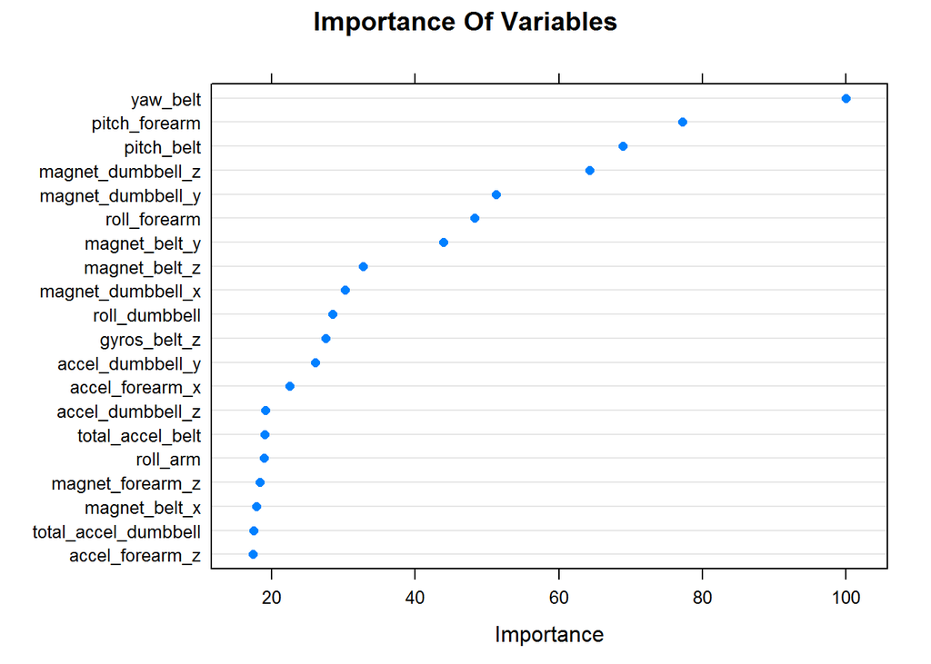

```r
dotPlot(varImp(mod1),main="Importance Of Variables")
```

Histogram below shows that values of metrics describing model prediction were about the same for most resampling cases. This shows our result is stable, so most likely reliable:

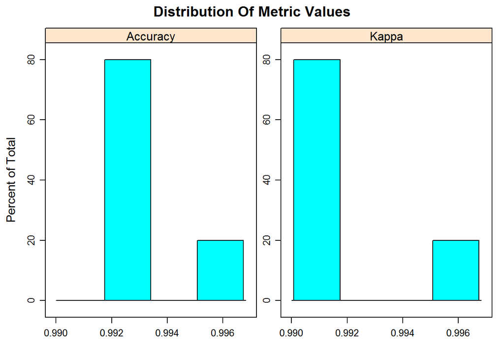

```r
resampleHist(mod1,type="hist",main="Distribution Of Metric Values")
```

The plot below demonstrates that OOB error rates decrease when number of trees increases, but it stabilizes on about 100 trees. So increasing number of trees in the model is not necessarily useful. The highest error rate keeps for class D, the lowest - for class A. This result is consistent with numbers in the confusion matrix above.

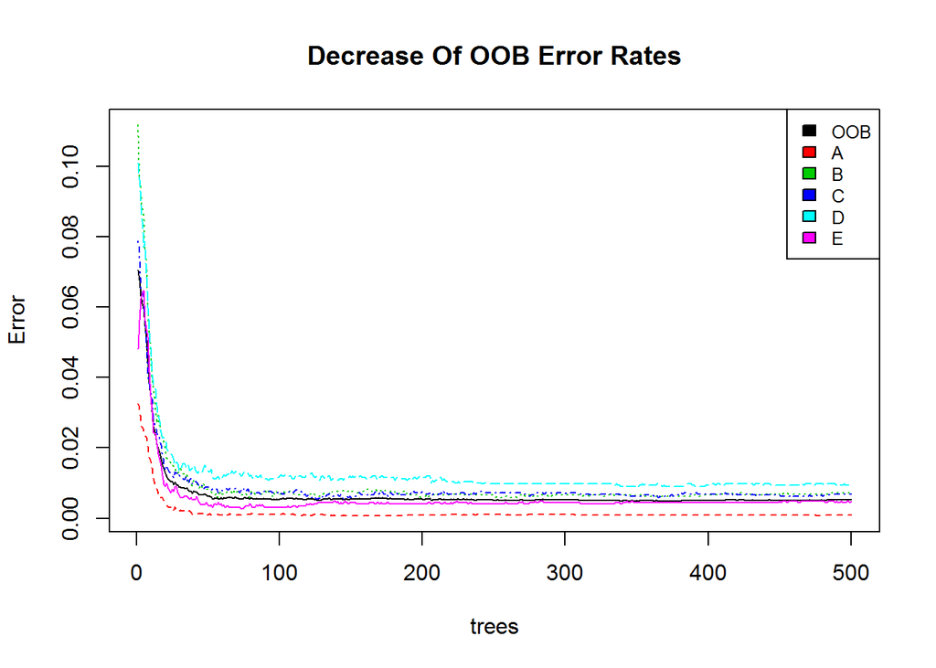

```r
plot(mod1$finalModel,main="Decrease Of OOB Error Rates")
legend("topright", colnames(mod1$finalModel$err.rate),col=1:6,cex=0.8,fill=1:6)
```

Also, frequencies that variables are used in the forest are calculated below:

```r
varUsed(mod1$finalModel)
```

```
##  [1] 14760 18594  3071  5475  4112  8246  8146  6787  8819  7374  5949
## [12]  5769  4725  7539  4407  6003  5801  5590  5447  6657  6080  7226
## [23]  5030  6558  4573  7991  5025  6821  7382  8989 10332 12267  9789
## [34] 10419  5594  3972  4663  6284  4890  7020  5384  6824  6088  6585
## [45]  8365
```

These are top 4 variables in usage frequency:

```r
varused<-cbind(1:length(varUsed(mod1$finalModel)),varUsed(mod1$finalModel))
varused<-varused[order(-varused[,2]),]
colnames(data1)[varused[1:4,1]]
```

```
## [1] "yaw_belt"          "pitch_belt"        "magnet_dumbbell_z"
## [4] "pitch_forearm"
```

These are the same top 4 predictors by importance. So we can guess that importance in the model is related to frequency of variable usage.

### Conclusion

We have analyzed the dataset containing information about different ways of weight lifting. The purpose of this analysis was to find out a way to predict the manner of the exercise, whether it is done correctly or not (4 possible mistakes). Unnecessary features were removed from the data, mainly due to lots of `NA` values, high correlation or because of information being useless to the prediction. Data was preprocessed (centered and scaled) to put all features on the same scale. Random forest algorithm related functions from `caret` and `randomForest` packages in `R` were selected for the prediction. In order to avoid overfitting, the dataset was split into training and testing subsets. After tuning necessary parameters, the final forest looks to have high accuracy on both training and testing sets, which indicates its efficiency.